# Data Analysis Project Report : Annual Employment Survey 2008 - 2017

Authors:

```
Ming Xin Shen - X00144407
Beatrice Esan - X00146407
Sarah Nabukeera - X00143947
```

#### The Dataset :

The Dataset chosen was the annual employment survey from 2008 to 2017 in Ireland. It has the employment amount for different sectors and regions for both full-time and part-time. It also has two columns for the employment growth in percentage from 2016 to 2017 and 2008 to 2017.

The type of data for the dataset values are ratio and interval because the values of employment are whole numbers and it doesn’t have any negative values. But the values for the percentage difference between the years is interval and continuous because some percentage values are negative.

For the project, the aim is to explore into the chosen dataset to see what information could be found. Some questions were raised and hypotheses were formed about the dataset, so the aim of these findings is to help answer these questions and hypotheses.

#### Work Division :

Ming

Clean and explore the data for the table with the employment of all sectors(full-time and part-time) from 2008 to 2017. Delete all commas and the % sign in the values. And create graphs that will give some information about the data, e.g. line graph, pie charts, bar charts etc.

Beatrice

Cleaned the data, removed commas from it, created tables and graphs to display all the information about the regions of employment between Dublin and other parts of the country. These include line graph, bar plot, grouped bar chart, two pie charts and a scatter plot.

Sarah

Exploring the dataset between Full time and Part time employment, comparing the employment growth level trend for a period of 10 years between 2008 and 2017. Finding the problem about the dataset, come up with the question and work around that question by finding the answer to it and hypothesis between part time and full time. Data cleaned and exploratories are listed below.

-The code below is to remove all the comma between the numbers of employment amount. It can only execute once, after the changes had been appeal to the csv, it will give error if you try to run it again.

```python
import pandas as pd
import matplotlib.pyplot as plt
import numpy as np


file = 'AES-2008-2017-Appendix-Tables-All-Companies.csv'
csvfile = pd.read_csv (file)

df = pd.DataFrame(csvfile, columns = ['All companies','2008','2009','2010','2011','2012','2013','2014','2015','2016','2017','% Change 2016-17','% Change 2008-17'])
df['2008'] = df['2008'].astype(str).str.replace(',','')
df['2009'] = df['2009'].astype(str).str.replace(',','')
df['2010'] = df['2010'].astype(str).str.replace(',','')
df['2011'] = df['2011'].astype(str).str.replace(',','')
df['2012'] = df['2012'].astype(str).str.replace(',','')
df['2013'] = df['2013'].astype(str).str.replace(',','')
df['2014'] = df['2014'].astype(str).str.replace(',','')
df['2015'] = df['2015'].astype(str).str.replace(',','')
df['2016'] = df['2016'].astype(str).str.replace(',','')
df['2017'] = df['2017'].astype(str).str.replace(',','')

print(df)
df.to_csv(file)
#end - passed
```

```
                                        All companies    2008    2009    2010  \
0                    Manufacturing and Other Industry  221218  197540  178412
1                 Basic and Fabricated Metal Products   14148   11206   10248
2                                           Chemicals   25971   24439   21955
3                      Clothing, Footwear and Leather    1816    1739    1453
4          Computer, Electronic and Optical Equipment   22212   19457   17759
5               Construction, Energy, Water and Waste   14586   12530   10952
6                                   Drink and Tobacco    6615    6648    5231
7                                Electrical Equipment    6663    5669    4928
8                                                Food   42605   40561   37751
9                             Machinery and Equipment   11953   10190    9617
10        Medical and dental instruments and supplies   23682   23932   21639
11  Miscellaneous Manufacturing and Agriculture, F...   10947    9467    8613
12                              Non-Metallic Minerals   10357    7045    5906
13                                 Paper and Printing    7234    6838    6010
```

[output cut: 80 more lines]

-To remove all the % sign for all the values in last two columns, it can only execute once, after the changes had been appeal to the csv, it will give error if you try to run it again.

```python
import pandas as pd
import matplotlib.pyplot as plt
import numpy as np

file = 'AES-2008-2017-Appendix-Tables-All-Companies.csv'
csvfile = pd.read_csv (file)

dfPercentage = pd.DataFrame(csvfile, columns = ['All companies','2008','2009','2010','2011','2012','2013','2014','2015','2016','2017','% Change 2016-17','% Change 2008-17'])
dfPercentage['% Change 2016-17'] = dfPercentage['% Change 2016-17'].str.replace('%','').astype(str)
dfPercentage['% Change 2008-17'] = dfPercentage['% Change 2008-17'].str.replace('%','').astype(str)

print(dfPercentage)

dfPercentage.to_csv(file)
#end - passed
```

```
                                        All companies    2008    2009    2010  \
0                    Manufacturing and Other Industry  221218  197540  178412
1                 Basic and Fabricated Metal Products   14148   11206   10248
2                                           Chemicals   25971   24439   21955
3                      Clothing, Footwear and Leather    1816    1739    1453
4          Computer, Electronic and Optical Equipment   22212   19457   17759
5               Construction, Energy, Water and Waste   14586   12530   10952
6                                   Drink and Tobacco    6615    6648    5231
7                                Electrical Equipment    6663    5669    4928
8                                                Food   42605   40561   37751
9                             Machinery and Equipment   11953   10190    9617
10        Medical and dental instruments and supplies   23682   23932   21639
11  Miscellaneous Manufacturing and Agriculture, F...   10947    9467    8613
12                              Non-Metallic Minerals   10357    7045    5906
13                                 Paper and Printing    7234    6838    6010
```

[output cut: 80 more lines]

-Graphs that got created during the exploratory of the dataset :

```
Try to create a bar chart to show the difference between the employment amount of Consultancy and Programming.
```

```
[28751, 34058]
[21535, 31557]
```

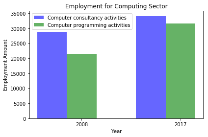

```python
import pandas as pd
import matplotlib.pyplot as plt
import numpy as np
#import seaborn as sns


file = 'AES-2008-2017-Appendix-Tables-All-Companies.csv'
csvfile = pd.read_csv (file)

df = pd.DataFrame(csvfile, columns = ['All companies','2008','2009','2010','2011','2012','2013','2014','2015','2016','2017','% Change 2016-17','% Change 2008-17'])

#Delete the row that's unnecessary and repeated
#df.drop([26], inplace = True)
#df.drop([27], inplace = True)
#df.drop([28], inplace = True)
#df.drop([29], inplace = True)
#df.drop([19], inplace = True)
#print(df)
#df.to_csv(file)

n_groups = 2
consultancy = [df.iloc[21,1], df.iloc[21,10]]
programming = [df.iloc[23,1], df.iloc[23,10]]
print(consultancy)
print(programming)
# create plot
fig, ax = plt.subplots()
index = np.arange(n_groups)
bar_width = 0.30
opacity = 0.6

rects1 = plt.bar(index, consultancy, bar_width,
alpha=opacity,
color='b',
label='Computer consultancy activities')

rects2 = plt.bar(index + bar_width, programming, bar_width,
alpha=opacity,
color='g',
label='Computer programming activities')

plt.xlabel('Year')
plt.ylabel('Employment Amount')
plt.title('Employment for Computing Sector')
plt.xticks(index + bar_width, ('2008', '2017'))
plt.legend()

plt.tight_layout()
plt.show()
#passed
```

```
A pie chart about the employment in 2017 for industry and service sectors.
```

```
808975
```

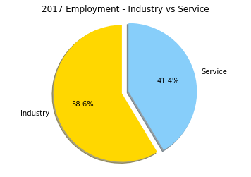

```python
import pandas as pd
import matplotlib.pyplot as plt
import numpy as np

file = 'AES-2008-2017-Appendix-Tables-All-Companies.csv'
csvfile = pd.read_csv (file)

df = pd.DataFrame(csvfile, columns = ['All companies','2008','2009','2010','2011','2012','2013','2014','2015','2016','2017','% Change 2016-17','% Change 2008-17'])


total = df.iloc[0,10] + df.iloc[1,10] + df.iloc[2,10] + df.iloc[3,10] + df.iloc[4,10] + df.iloc[5,10] + df.iloc[6,10] + df.iloc[7,10] + df.iloc[8,10] + df.iloc[9,10] + df.iloc[10,10] + df.iloc[11,10] + df.iloc[12,10] + df.iloc[13,10] + df.iloc[14,10] + df.iloc[15,10] + df.iloc[16,10] + df.iloc[17,10] + df.iloc[18,10] + df.iloc[19,10] + df.iloc[20,10] + df.iloc[21,10] + df.iloc[22,10] + df.iloc[23,10] + df.iloc[24,10]

Industry = (df.iloc[0,10] + df.iloc[1,10] + df.iloc[2,10] + df.iloc[3,10] + df.iloc[4,10] + df.iloc[5,10] + df.iloc[6,10] + df.iloc[7,10] + df.iloc[8,10] + df.iloc[9,10] + df.iloc[10,10] + df.iloc[11,10] + df.iloc[12,10] + df.iloc[13,10] + df.iloc[14,10] + df.iloc[15,10] + df.iloc[16,10] + df.iloc[17,10] + df.iloc[18,10]) / total

Service = (df.iloc[19,10] + df.iloc[20,10] + df.iloc[21,10] + df.iloc[22,10] + df.iloc[23,10] + df.iloc[24,10]) / total

print(total)

labels = 'Industry', 'Service'

#total = 0
#for x in range(24):
  #total += df.iloc[x, 10]

#Industry = 0
#for x in range(19):
  #Industry += df.iloc[x, 10]

#Service = 0
#for x in range(19,24):
  #Service += df.iloc[x, 10]

sizes = [Industry, Service]
colors = ['gold', 'lightskyblue']
explode = (0.1, 0)  # explode 1st slice

plt.pie(sizes, explode=explode, labels=labels, colors=colors,
autopct='%1.1f%%', shadow=True, startangle=90)
plt.axis('equal')
plt.title('2017 Employment - Industry vs Service')
plt.show()
#passed
```

```
A scatter plot for the employment amount of Consultancy and Programming
```

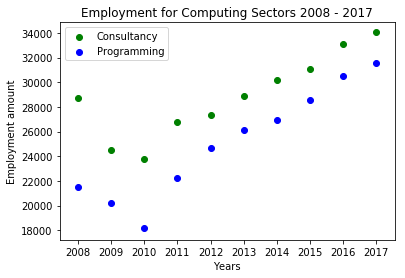

```python
import pandas as pd
import matplotlib.pyplot as plt
import numpy as np

file = 'AES-2008-2017-Appendix-Tables-All-Companies.csv'
csvfile = pd.read_csv (file)

df = pd.DataFrame(csvfile, columns = ['All companies','2008','2009','2010','2011','2012','2013','2014','2015','2016','2017','% Change 2016-17','% Change 2008-17'])


consultancy =  [df.iloc[21,1], df.iloc[21,2], df.iloc[21,3], df.iloc[21,4], df.iloc[21,5], df.iloc[21,6], df.iloc[21,7], df.iloc[21,8], df.iloc[21,9], df.iloc[21,10]]
programming =  [df.iloc[23,1], df.iloc[23,2], df.iloc[23,3], df.iloc[23,4], df.iloc[23,5], df.iloc[23,6], df.iloc[23,7], df.iloc[23,8], df.iloc[23,9], df.iloc[23,10]]
year = ['2008', '2009', '2010', '2011', '2012', '2013', '2014', '2015', '2016', '2017']

plt.scatter(year, consultancy, color='green', label='Consultancy')
plt.scatter(year, programming, color='blue', label='Programming')
plt.legend()
plt.xlabel('Years')
plt.ylabel('Employment amount')
plt.title('Employment for Computing Sectors 2008 - 2017')
plt.show()
#passed
```

## Ming Xin Shen

Employment Growth for Computing Sectors - Ming

For the dataset, there are a few questions about the table of all the employment for all sectors (full-time and part-time). The questions are the following :

```
Which sector had the highest employment, Consultancy or Programming ?

What’s the employment growth for the computing sectors in 2008 vs 2017, and why ?

How many percentage does Computing sectors takes out of all the sectors (Industry and Service) ?
```

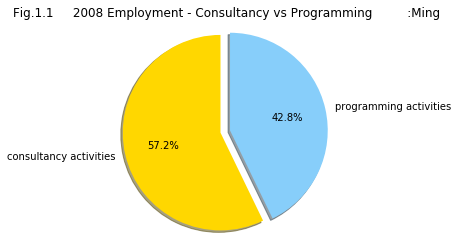

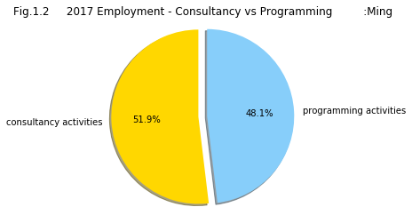

```python
#pie chart to compare consultancy and programming sectors
import pandas as pd
import matplotlib.pyplot as plt
import numpy as np

file = 'AES-2008-2017-Appendix-Tables-All-Companies.csv'
csvfile = pd.read_csv (file)

df = pd.DataFrame(csvfile, columns = ['All companies','2008','2009','2010','2011','2012','2013','2014','2015','2016','2017','% Change 2016-17','% Change 2008-17'])



#2008 pie chart
labels = 'consultancy activities', 'programming activities'
total = df.iloc[21,1] + df.iloc[23,1]
consultancy = df.iloc[21,1] / total
programming = df.iloc[23,1] / total

sizes = [consultancy, programming]
colors = ['gold', 'lightskyblue']
explode = (0.1, 0)  # explode 1st slice

plt.pie(sizes, explode=explode, labels=labels, colors=colors,
autopct='%1.1f%%', shadow=True, startangle=90)
plt.axis('equal')
plt.title('Fig.1.1     2008 Employment - Consultancy vs Programming         :Ming')
plt.show()



#2017 pie chart
total = df.iloc[21,10] + df.iloc[23,10]
consultancy = df.iloc[21,10] / total
programming = df.iloc[23,10] / total

sizes = [consultancy, programming]
colors = ['gold', 'lightskyblue']
explode = (0.1, 0)  # explode 1st slice

plt.pie(sizes, explode=explode, labels=labels, colors=colors,
autopct='%1.1f%%', shadow=True, startangle=90)
plt.axis('equal')
plt.title('Fig.1.2     2017 Employment - Consultancy vs Programming         :Ming')
plt.show()
#end - passed
```

From Fig.1.1 and Fig.1.2 above, the percentage of employment for consultancy sector are higher than programming, so consultancy had the highest employment for both years. But from the diagrams above, programming sector had grown a lot since 2008. In 2008, programming only had 42% and consultancy had 57%. In 2017, programming had grown to 48% and consultancy had decreased to 51%. So both sectors each had almost 50% of employment in 2017.

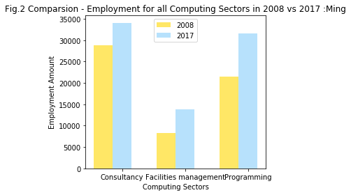

```python
import pandas as pd
import matplotlib.pyplot as plt
import numpy as np

#2017 Employment pie chart for industry and service sectors
file = 'AES-2008-2017-Appendix-Tables-All-Companies.csv'
csvfile = pd.read_csv (file)

df = pd.DataFrame(csvfile, columns = ['All companies','2008','2009','2010','2011','2012','2013','2014','2015','2016','2017','% Change 2016-17','% Change 2008-17'])

#comparsion - bar chart for all computing sectors in 2008 and 2017
n_groups = 3
year2008 = [df.iloc[21,1], df.iloc[22,1], df.iloc[23,1]]
year2017 = [df.iloc[21,10], df.iloc[22,10], df.iloc[23,10]]

# create plot
fig, ax = plt.subplots()
index = np.arange(n_groups)
bar_width = 0.30
opacity = 0.6

rects1 = plt.bar(index, year2008, bar_width,
alpha=opacity,
color='gold',
label='2008')

rects2 = plt.bar(index + bar_width, year2017, bar_width,
alpha=opacity,
color='lightskyblue',
label='2017')

plt.xlabel('Computing Sectors')
plt.ylabel('Employment Amount')
plt.title('Fig.2 Comparsion - Employment for all Computing Sectors in 2008 vs 2017 :Ming')
plt.xticks(index + bar_width, ('Consultancy', 'Facilities management', 'Programming'))
plt.legend()
plt.tight_layout()
plt.show()
```

From Fig.2, consultancy had employed 28,751 people and programming only employed 21,535 people in 2008. Consultancy had ⅓ percentage more employment than programming. Consultancy had that much employment because in 2008, the technology wasn’t known by many people so when people use computers or technical products, they had lots of questions about it. Like how to use it, and when some errors occur, what should they do to fix it. Programming had less employment because at that time, the needs of people developing/coding wasn’t much. But as technology developed, more and more people get to know more about internet, computers … e.c.

So in 2017, the needs of programmers had increased massively. The employment for consultancy sector hadn’t grown too much because people know more about technology (how to use computers/internet e.c.) and people can search online when they have any questions/errors so less people need consultancy.

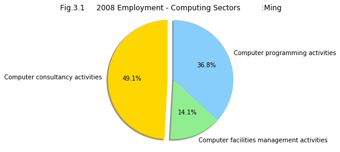

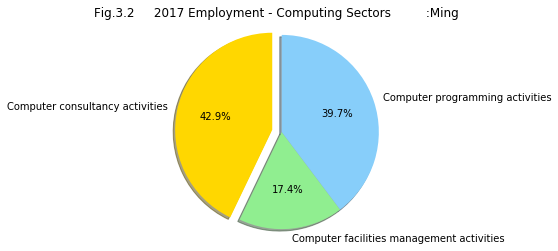

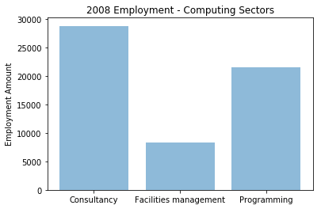

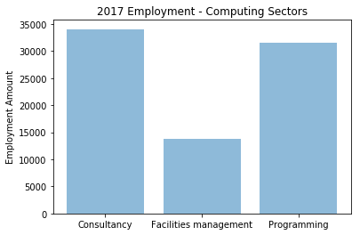

```python
#pie charts and bar graphs for all computing sectors in 2008 and 2017
import pandas as pd
import matplotlib.pyplot as plt
import numpy as np

file = 'AES-2008-2017-Appendix-Tables-All-Companies.csv'
csvfile = pd.read_csv (file)

df = pd.DataFrame(csvfile, columns = ['All companies','2008','2009','2010','2011','2012','2013','2014','2015','2016','2017','% Change 2016-17','% Change 2008-17'])



#pie chart for all computing sectors in 2008
labels = 'Computer consultancy activities', 'Computer facilities management activities', 'Computer programming activities'
total = df.iloc[21,1] + df.iloc[22,1] + df.iloc[23,1]
consultancy = df.iloc[21,1] / total
facilities = df.iloc[22,1] / total
programming = df.iloc[23,1] / total

sizes = [consultancy, facilities, programming]
colors = ['gold', 'lightgreen', 'lightskyblue']
explode = (0.1, 0, 0)  # explode 1st slice

plt.pie(sizes, explode=explode, labels=labels, colors=colors,
autopct='%1.1f%%', shadow=True, startangle=90)
plt.axis('equal')
plt.title('Fig.3.1     2008 Employment - Computing Sectors         :Ming')
plt.show()



#pie chart for all computing sectors in 2017
labels = 'Computer consultancy activities', 'Computer facilities management activities', 'Computer programming activities'
total = df.iloc[21,10] + df.iloc[22,10] + df.iloc[23,10]
consultancy = df.iloc[21,10] / total
facilities = df.iloc[22,10] / total
programming = df.iloc[23,10] / total

sizes = [consultancy, facilities, programming]
colors = ['gold', 'lightgreen', 'lightskyblue']
explode = (0.1, 0, 0)  # explode 1st slice

plt.pie(sizes, explode=explode, labels=labels, colors=colors,
autopct='%1.1f%%', shadow=True, startangle=90)
plt.axis('equal')
plt.title('Fig.3.2     2017 Employment - Computing Sectors         :Ming')
plt.show()






#bar chart for all computing sectors in 2008
computing = ('Consultancy', 'Facilities management', 'Programming')
y_pos = np.arange(len(computing))
sector = [df.iloc[21,1], df.iloc[22,1], df.iloc[23,1]]

plt.bar(y_pos, sector, align='center', alpha=0.5)
plt.xticks(y_pos, computing)
plt.ylabel('Employment Amount')
plt.title('2008 Employment - Computing Sectors')
plt.show()



#bar chart for all computing sectors 2017
computing = ('Consultancy', 'Facilities management', 'Programming')
y_pos = np.arange(len(computing))
sector = [df.iloc[21,10], df.iloc[22,10], df.iloc[23,10]]

plt.bar(y_pos, sector, align='center', alpha=0.5)
plt.xticks(y_pos, computing)
plt.ylabel('Employment Amount')
plt.title('2017 Employment - Computing Sectors')
plt.show()
#end - passed
```

In Fig.3.2, facilities management sector had the lowest employment rate than other sectors. That’s because in 2017, virtualization and cloud storage appears which means lots of companies don’t need to employ people to take care of the servers when they can just pay for the cloud service that some companies provide.And because of the rapid growth of the technology, it’s easier to manage facilities than in the past.

So the management for facilities isn’t much, which caused the low employment for the facilities management sector. In 2008, the employment of facilities management sector are 8,245. It's even less than ⅓ of employment for consultancy at that year.

From Fig.2, programming and facilities management sectors had increased massively over the 9 years from 2008 to 2017. Programming sector had increased almost 50% of employment and facilities management had increased about 68%. It grown that much because of the massive development in technology.

As the technology grows, the need for programming and facilities management increases with it as well. More programmers are needed to develop software and to manage the network(switch, hub), servers, computers that companies have. Consultancy sector had only increased around 20% of employment since 2008. It increased around 5,000 employment during the 9 years but programming had increased more than 10,000 employment. So consultancy only increased ½ of programming’s employment. So the employment of the two sectors(Consultancy and Programming) have an effect on each other.

```python
import pandas as pd
import numpy as np

file = 'percentage_computing.csv'
csvfile = pd.read_csv(file)

df = pd.DataFrame(csvfile, columns = ['All Sectors','2008-2009','2009-2010','2010-2011','2011-2012','2012-2013','2013-2014','2014-2015','2015-2016','2016-2017'])
print("Fig.4.1     Employment Growth(%) for Consultancy vs Programming in 2008 - 2017         :Ming")
df.head()
```

```
Fig.4.1     Employment Growth(%) for Consultancy vs Programming in 2008 - 2017         :Ming
```

|  | All Sectors | 2008-2009 | 2009-2010 | 2010-2011 | 2011-2012 | 2012-2013 | 2013-2014 | 2014-2015 | 2015-2016 | 2016-2017 |
| --- | --- | --- | --- | --- | --- | --- | --- | --- | --- | --- |
| 0 | Consultancy | -14.69% | -3.07% | 12.67% | 2.14% | 5.59% | 4.54% | 2.88% | 6.52% | 2.89% |
| 1 | Programming | -5.99% | -10.16% | 22.15% | 10.94% | 6.13% | 3.10% | 5.96% | 6.81% | 3.40% |

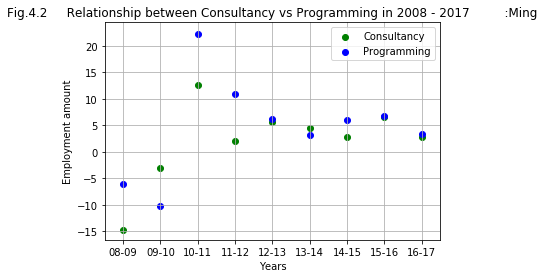

```python
#Scatter plot to show the relationship between Computing sectors in percentage % - Consultancy vs Programming from 2008 to 2017
import pandas as pd
import matplotlib.pyplot as plt
import numpy as np

file = 'AES-2008-2017-Appendix-Tables-All-Companies.csv'
csvfile = pd.read_csv (file)

df = pd.DataFrame(csvfile, columns = ['All companies','2008','2009','2010','2011','2012','2013','2014','2015','2016','2017','% Change 2016-17','% Change 2008-17'])


#consultancy =  [df.iloc[21,1], df.iloc[21,2], df.iloc[21,3], df.iloc[21,4], df.iloc[21,5], df.iloc[21,6], df.iloc[21,7], df.iloc[21,8], df.iloc[21,9], df.iloc[21,10]]
#programming =  [df.iloc[23,1], df.iloc[23,2], df.iloc[23,3], df.iloc[23,4], df.iloc[23,5], df.iloc[23,6], df.iloc[23,7], df.iloc[23,8], df.iloc[23,9], df.iloc[23,10]]
year = ['08-09', '09-10', '10-11', '11-12', '12-13', '13-14', '14-15', '15-16', '16-17']
consultancy = [-14.69, -3.07, 12.67, 2.14, 5.59, 4.54, 2.88, 6.52, 2.89]
programming =  [-5.99, -10.16, 22.15, 10.94, 6.13, 3.10, 5.96, 6.81, 3.40]
#consultancy = ['-14.69', '-3.07', '12.67', '2.14', '5.59', '4.54', '2.88', '6.52', '2.89']
#programming =  ['-5.99', '-10.16', '22.15', '10.94', '6.13', '3.10', '5.96', '6.81', '3.40']

'''
i = 0
for i in range(9):
    x = consultancy[i]
    y = consultancy[i+1]
    percentage = 0


    if (x/y) > 1:
        percentage = -( (x - y) / x )
        consultancy[i] = percentage


    else:
        percentage = -( (y - x) / x )
        consultancy[i] = percentage
    print(consultancy[i])

del consultancy[-1]

i = 0
for i in range(9):
    x = programming[i]
    y = programming[i+1]
    percentage = 0


    if (x/y) > 1:
        percentage = -( (x - y) / x )
        programming[i] = percentage


    else:
        percentage = -( (y - x) / x )
        programming[i] = percentage
    print(programming[i])

del programming[-1]
'''

plt.scatter(year, consultancy, color='green', label='Consultancy')
plt.scatter(year, programming, color='blue', label='Programming')
plt.legend()
plt.xlabel('Years')
plt.ylabel('Employment amount')
plt.title('Fig.4.2     Relationship between Consultancy vs Programming in 2008 - 2017         :Ming')
plt.grid(b=True)
plt.show()
#end - passed
```

So the employment of programming will have an effect on consultancy’s employment. But as time went by, the employment for both consultancy and programming had been increasing since 2011. The need for consultancy and programmers are high(more new software developed by programmers, more people had questions about the new software), so the increased percentage are quite similar.

From 2012 to 2017, the increased amount of employment are around 2% to 6%. Although, the increased percentage are similar, but both sectors still have an effect on each other because consultancy only increased 5,000 employment over the 9 years but programming increased more than 10,000.

#### Hypotheses :

```
-Since there has been rapid growth in technology, have the employment for the computing sectors increase around 50% ?

-Are the employment of Consultancy sector higher than Programming sector over the 9 years ?
```

#### T-Test :

A t-test are done on one of the hypotheses which is employment of Consultancy are higher than Programming.

The result that it shows for the t value and T-table value are :

```
t = 2.1384197
T-table value = 3.250
```

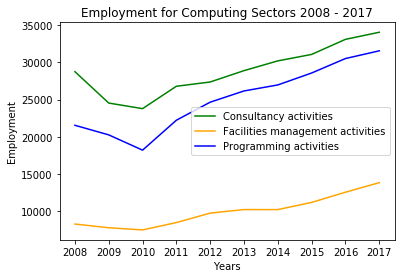

```
[58531, 52515, 49415, 57447, 61723, 65238, 67357, 70802, 76148, 79428]
[444332, 396859, 358364, 387325, 392766, 401925, 414956, 437851, 454414, 474336]
[223697, 208141, 193258, 224760, 236506, 251519, 272575, 293683, 315904, 334639]
```

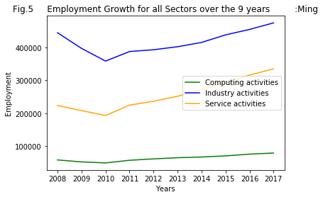

```python
#Line graph to see the growth for all sectors from 2008 to 2017
import pandas as pd
import matplotlib.pyplot as plt
import numpy as np

file = 'AES-2008-2017-Appendix-Tables-All-Companies.csv'
csvfile = pd.read_csv (file)

df = pd.DataFrame(csvfile, columns = ['All companies','2008','2009','2010','2011','2012','2013','2014','2015','2016','2017','% Change 2016-17','% Change 2008-17'])



#line graph for all sectors in Computing from 2008 to 2017
consultancy =  [df.iloc[21,1], df.iloc[21,2], df.iloc[21,3], df.iloc[21,4], df.iloc[21,5], df.iloc[21,6], df.iloc[21,7], df.iloc[21,8], df.iloc[21,9], df.iloc[21,10]]
facilities =  [df.iloc[22,1], df.iloc[22,2], df.iloc[22,3], df.iloc[22,4], df.iloc[22,5], df.iloc[22,6], df.iloc[22,7], df.iloc[22,8], df.iloc[22,9], df.iloc[22,10]]
programming =  [df.iloc[23,1], df.iloc[23,2], df.iloc[23,3], df.iloc[23,4], df.iloc[23,5], df.iloc[23,6], df.iloc[23,7], df.iloc[23,8], df.iloc[23,9], df.iloc[23,10]]
year = ['2008', '2009', '2010', '2011', '2012', '2013', '2014', '2015', '2016', '2017']

plt.plot(year, consultancy, color='green', label='Consultancy activities')
plt.plot(year, facilities, color='orange', label='Facilities management activities')
plt.plot(year, programming, color='blue', label='Programming activities')
plt.xlabel('Years')
plt.ylabel('Employment')
plt.title('Employment for Computing Sectors 2008 - 2017')
plt.legend(loc=0)
plt.show()






#line graph for all sectors in Industry, Service and Computing from 2008 to 2017
computing = []
Industry = [0, 0, 0, 0, 0, 0, 0, 0, 0, 0]
Service = [0, 0, 0, 0, 0, 0, 0, 0, 0, 0]
x=0
for x in range(10):
    computing.append(consultancy[x])

x=0
for x in range(10):
    computing[x] = computing[x] + facilities[x]

x=0
for x in range(10):
    computing[x] = computing[x] + programming[x]

print(computing)


df_Industry = pd.DataFrame(csvfile, columns = ['2008','2009','2010','2011','2012','2013','2014','2015','2016','2017'])
df_Industry = df_Industry.loc[0:18, :]

df_Service = pd.DataFrame(csvfile, columns = ['2008','2009','2010','2011','2012','2013','2014','2015','2016','2017'])
df_Service = df_Service.loc[19:24, :]


x=0
for x in range(19):
    count=0
    for y in range(0, 10):
        #print(df_Industry.iloc[x,y])
        Industry[count] = Industry[count] + df_Industry.iloc[x,y]
        count = count+1

print(Industry)

x=0
for x in range(6):
    count=0
    for y in range(0, 10):
        Service[count] = Service[count] + df_Service.iloc[x,y]
        count = count+1

print(Service)


year = ['2008', '2009', '2010', '2011', '2012', '2013', '2014', '2015', '2016', '2017']
#Industry = [df.iloc[0,1], df.iloc[1,1], df.iloc[2,1], df.iloc[3,1], df.iloc[4,1], df.iloc[5,1], df.iloc[6,1], df.iloc[7,1], df.iloc[8,1], df.iloc[9,1], df.iloc[10,1], df.iloc[11,1], df.iloc[12,1], df.iloc[13,1], df.iloc[14,1], df.iloc[15,1], df.iloc[16,1], df.iloc[17,1], df.iloc[18,1]]
#Service = [df.iloc[19,1] + df.iloc[20,1] + df.iloc[24,1], df.iloc[19,2] + df.iloc[20,2] + df.iloc[24,2], df.iloc[19,3] + df.iloc[20,3] + df.iloc[24,3], df.iloc[19,4] + df.iloc[20,4] + df.iloc[24,4], df.iloc[19,5] + df.iloc[20,5] + df.iloc[24,5], df.iloc[19,6] + df.iloc[20,6] + df.iloc[24,6], df.iloc[19,7] + df.iloc[20,7] + df.iloc[24,7], df.iloc[19,8] + df.iloc[20,8] + df.iloc[24,8], df.iloc[19,9] + df.iloc[20,9] + df.iloc[24,9], df.iloc[19,10] + df.iloc[20,10] + df.iloc[24,10]]


plt.plot(year, computing, color='green', label='Computing activities')
plt.plot(year, Industry, color='blue', label='Industry activities')
plt.plot(year, Service, color='orange', label='Service activities')
plt.xlabel('Years')
plt.ylabel('Employment')
plt.title('Fig.5     Employment Growth for all Sectors over the 9 years         :Ming')
plt.legend(loc=0)
plt.show()
#end - passed
```

The line graph(Fig.5) above shows the employment growth for Industry, Service and Computing sectors(Computing are included in the service sectors, but it’s plotted in the line graph because it shows what does the line for Computing sector looks like, was it increasing all the time?). From Fig.5, Industry sectors had the highest employment amount than the Service and Computing sectors. However, from 2008 to 2010, the employment for all sectors had been decreasing during the past two years.

The reason for the massive decrease of employment caused 2010 had the lowest employment over the 9 years are because the financial crisis/recession happened that year caused a lot of people lost their jobs. Although the recession happened in 2010 had a huge effect on the employment for all sectors. In 2011, the employment had started increasing after 2010. All sectors had been increasing employment since 2011, especially for computing sectors. After 2010, Computing sectors had always increasing the employment(from scatter plot Fig.4.2 and the table Fig.4.1).

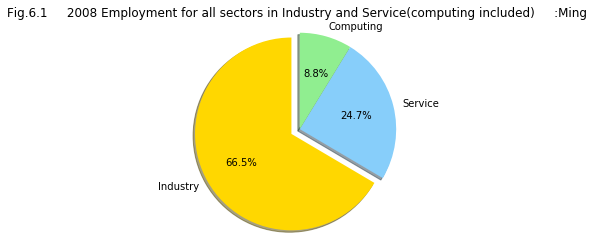

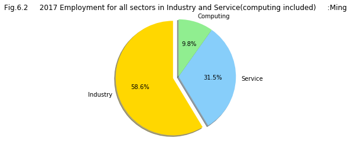

```python
#The code for plot pie chart for Industry, Service and Computing sectors
import pandas as pd
import matplotlib.pyplot as plt
import numpy as np

file = 'AES-2008-2017-Appendix-Tables-All-Companies.csv'
csvfile = pd.read_csv (file)

df = pd.DataFrame(csvfile, columns = ['All companies','2008','2009','2010','2011','2012','2013','2014','2015','2016','2017','% Change 2016-17','% Change 2008-17'])



#pie chart for all sectors in industry, service and computing at 2008
total = df.iloc[0,1] + df.iloc[1,1] + df.iloc[2,1] + df.iloc[3,1] + df.iloc[4,1] + df.iloc[5,1] + df.iloc[6,1] + df.iloc[7,1] + df.iloc[8,1] + df.iloc[9,1] + df.iloc[10,1] + df.iloc[11,1] + df.iloc[12,1] + df.iloc[13,1] + df.iloc[14,1] + df.iloc[15,1] + df.iloc[16,1] + df.iloc[17,1] + df.iloc[18,1] + df.iloc[19,1] + df.iloc[20,1] + df.iloc[21,1] + df.iloc[22,1] + df.iloc[23,1] + df.iloc[24,1]

Industry = (df.iloc[0,1] + df.iloc[1,1] + df.iloc[2,1] + df.iloc[3,1] + df.iloc[4,1] + df.iloc[5,1] + df.iloc[6,1] + df.iloc[7,1] + df.iloc[8,1] + df.iloc[9,1] + df.iloc[10,1] + df.iloc[11,1] + df.iloc[12,1] + df.iloc[13,1] + df.iloc[14,1] + df.iloc[15,1] + df.iloc[16,1] + df.iloc[17,1] + df.iloc[18,1]) / total

Service = (df.iloc[19,1] + df.iloc[20,1] + df.iloc[24,1]) / total

Computing = (df.iloc[21,1] + df.iloc[22,1] + df.iloc[23,1]) / total

labels = 'Industry', 'Service' , 'Computing'
sizes = [Industry, Service, Computing]
colors = ['gold', 'lightskyblue', 'lightgreen']
explode = (0.1, 0, 0)  # explode 1st slice

plt.pie(sizes, explode=explode, labels=labels, colors=colors,
autopct='%1.1f%%', shadow=True, startangle=90)
plt.axis('equal')
plt.title('Fig.6.1     2008 Employment for all sectors in Industry and Service(computing included)     :Ming')
plt.show()



#pie chart for all sectors in industry, service and computing at 2017
total = df.iloc[0,10] + df.iloc[1,10] + df.iloc[2,10] + df.iloc[3,10] + df.iloc[4,10] + df.iloc[5,10] + df.iloc[6,10] + df.iloc[7,10] + df.iloc[8,10] + df.iloc[9,10] + df.iloc[10,10] + df.iloc[11,10] + df.iloc[12,10] + df.iloc[13,10] + df.iloc[14,10] + df.iloc[15,10] + df.iloc[16,10] + df.iloc[17,10] + df.iloc[18,10] + df.iloc[19,10] + df.iloc[20,10] + df.iloc[21,10] + df.iloc[22,10] + df.iloc[23,10] + df.iloc[24,10]

Industry = (df.iloc[0,10] + df.iloc[1,10] + df.iloc[2,10] + df.iloc[3,10] + df.iloc[4,10] + df.iloc[5,10] + df.iloc[6,10] + df.iloc[7,10] + df.iloc[8,10] + df.iloc[9,10] + df.iloc[10,10] + df.iloc[11,10] + df.iloc[12,10] + df.iloc[13,10] + df.iloc[14,10] + df.iloc[15,10] + df.iloc[16,10] + df.iloc[17,10] + df.iloc[18,10]) / total

Service = (df.iloc[19,10] + df.iloc[20,10] + df.iloc[24,10]) / total

Computing = (df.iloc[21,10] + df.iloc[22,10] + df.iloc[23,10]) / total

labels = 'Industry', 'Service' , 'Computing'

#total = 0
#for x in range(24):
  #total += df.iloc[x, 10]

#Industry = 0
#for x in range(19):
  #Industry += df.iloc[x, 10]

#Service = 0
#for x in range(19,24):
  #Service += df.iloc[x, 10]


sizes = [Industry, Service, Computing]
colors = ['gold', 'lightskyblue', 'lightgreen']
explode = (0.1, 0, 0)  # explode 1st slice

plt.pie(sizes, explode=explode, labels=labels, colors=colors,
autopct='%1.1f%%', shadow=True, startangle=90)
plt.axis('equal')
plt.title('Fig.6.2     2017 Employment for all sectors in Industry and Service(computing included)     :Ming')
plt.show()
#end - passed
```

#### Conclusion :

There are a rapid growth for the computing sectors because it had grown from around 8% of employment out of all sectors to had almost 10% out of all sectors. It might not seem that much from percentage(%) point of view, but it had increased 20,897 employment for the computing sectors over the 9 years. From the table above Fig.5 and the line graph(Fig.5), the employment for computing had been growing/increasing since 2011, so the years after 2017 is estimated to be increasing as well.